# Penguin data wrangling

## Introduction

The aim of this exercise is to practice your data-wrangling skills using the penguins dataset. You should be able to solve the exercise after studying the introduction to data wrangling on Moodle (both document and video) and occasionally you may need to confront the help file for a given function. (You also need your previous knowledge about `ggplot` to produce the relevant graphs.)

You are asked to use the exercise qmd file (this file) as a starting point and modify it to answer all parts of the exercise. The file should “work out of the box” in the sense that once you have downloaded the file and opened it in RStudio you can press “Render/Knit” (Ctrl+Shift+K) and a rendered html document should pop-up. Several R code chunks later on needs to be modified by you to work correctly and they have been disabled by setting the chunk option `eval: false`. Once you start working on the exercise you can press the “play button” (Ctrl+Shift+Enter inside the chunk) chunk by chunk as you progress. Once a given chunk is working correctly you can delete or change the option `eval: false` and press “Render/Knit” (Ctrl+Shift+K) to see that the entire document is still rendering correctly.

We start by loading the `tidyverse` package:

```r
library(tidyverse)
```

Then we save the data with a shorter name (this requires that you have the package `palmerpenguins` installed, so please do so if you haven’t already done it by now):

```r
pengu <- palmerpenguins::penguins
```

## Exercises

This command makes a new dataset `big_flipper_female` of female penguins with a flipper length above a certain threshold:

```r
big_flipper_female <- pengu |>
  filter(sex == "female" & flipper_length_mm>200)
```

### Exercise 1

```r
male_2007 <- pengu |>
  filter(sex == "male")
male_2007
```

```
# A tibble: 168 × 8
   species island    bill_length_mm bill_depth_mm flipper_length_mm body_mass_g
   <fct>   <fct>              <dbl>         <dbl>             <int>       <int>
 1 Adelie  Torgersen           39.1          18.7               181        3750
 2 Adelie  Torgersen           39.3          20.6               190        3650
 3 Adelie  Torgersen           39.2          19.6               195        4675
 4 Adelie  Torgersen           38.6          21.2               191        3800
 5 Adelie  Torgersen           34.6          21.1               198        4400
 6 Adelie  Torgersen           42.5          20.7               197        4500
 7 Adelie  Torgersen           46            21.5               194        4200
 8 Adelie  Biscoe              37.7          18.7               180        3600
 9 Adelie  Biscoe              38.2          18.1               185        3950
10 Adelie  Biscoe              38.8          17.2               180        3800
# ℹ 158 more rows
# ℹ 2 more variables: sex <fct>, year <int>
```

### Exercise 2

```r
male_2007 |>
  group_by(island) |>
  summarise(mean_mass = mean(body_mass_g, na.rm = TRUE))
```

```
# A tibble: 3 × 2
  island    mean_mass
  <fct>         <dbl>
1 Biscoe        5105.
2 Dream         3987.
3 Torgersen     4035.
```

### Exercise 3

What was the mean body mass of male penguins for each island in 2009? (Insert a new chunk of R code (Ctrl+Shift+K) with the relevant code)

```r
pengu |>
  filter(sex == "male", year == 2009) |>
  group_by(island) |>
  summarise(mean_mass = mean(body_mass_g, na.rm = TRUE))
```

```
# A tibble: 3 × 2
  island    mean_mass
  <fct>         <dbl>
1 Biscoe        5168.
2 Dream         3935.
3 Torgersen     3784.
```

### Exercise 4

Make a dataset `Adelie_small` only containing the mass and sex of `Adelie` penguins disregarding all other columns. (Hint: Use both `select()` and `filter()`)

```r
Adelie_small <- pengu |>
  filter(species == "Adelie") |>
  select(body_mass_g, sex)
Adelie_small
```

```
# A tibble: 152 × 2
   body_mass_g sex
         <int> <fct>
 1        3750 male
 2        3800 female
 3        3250 female
 4          NA <NA>
 5        3450 female
 6        3650 male
 7        3625 female
 8        4675 male
 9        3475 <NA>
10        4250 <NA>
# ℹ 142 more rows
```

### Exercise 5

Arrange the data from the previous exercise (4) such that the penguins with lowest mass are at the top of the table? (Hint: Insert a new code chunk and use `arrange()`)

```r
Adelie_small |> arrange(body_mass_g)
```

```
# A tibble: 152 × 2
   body_mass_g sex
         <int> <fct>
 1        2850 female
 2        2850 female
 3        2900 female
 4        2900 female
 5        2900 female
 6        2925 female
 7        2975 <NA>
 8        3000 female
 9        3000 female
10        3050 female
# ℹ 142 more rows
```

### Exercise 6

Some penguins have the same body mass. Use arrange in the same way as in the previous exercise (5), but such that ties are broken by also arranging after bill length and bill depth. (Hint: Insert a new code chunk and provide several arguments in `arrange()`)

**EDIT: We have to do this with the full dataset since bill depth and length are omitted in the data from the previous exercise.**

```r
pengu |> arrange(body_mass_g, bill_length_mm, bill_depth_mm)
```

```
# A tibble: 344 × 8
   species   island   bill_length_mm bill_depth_mm flipper_length_mm body_mass_g
   <fct>     <fct>             <dbl>         <dbl>             <int>       <int>
 1 Chinstrap Dream              46.9          16.6               192        2700
 2 Adelie    Biscoe             36.4          17.1               184        2850
 3 Adelie    Biscoe             36.5          16.6               181        2850
 4 Adelie    Dream              33.1          16.1               178        2900
 5 Adelie    Biscoe             34.5          18.1               187        2900
 6 Adelie    Torgers…           38.6          17                 188        2900
 7 Chinstrap Dream              43.2          16.6               187        2900
 8 Adelie    Biscoe             37.9          18.6               193        2925
 9 Adelie    Dream              37.5          18.9               179        2975
10 Adelie    Dream              37            16.9               185        3000
# ℹ 334 more rows
# ℹ 2 more variables: sex <fct>, year <int>
```

### Exercise 7

Extend the `pengu` dataset such that it contains an extra column called `body_mass_kg` containing the penguin mass measured in kg and call the resulting dataset `pengu2`. (Hint: Insert a new chunk and use `mutate()`.)

```r
pengu2 <- pengu |>
  mutate(body_mass_kg = body_mass_g/1000)
```

### Exercise 8

Make a scatter plot (`geom_point()`) showing the perfect linear relationship between the penguin mass in grams (on horizontal axis) and kilograms (on vertical axis). (*Remember* to change the chunk option when you have modified the code below to work correctly)

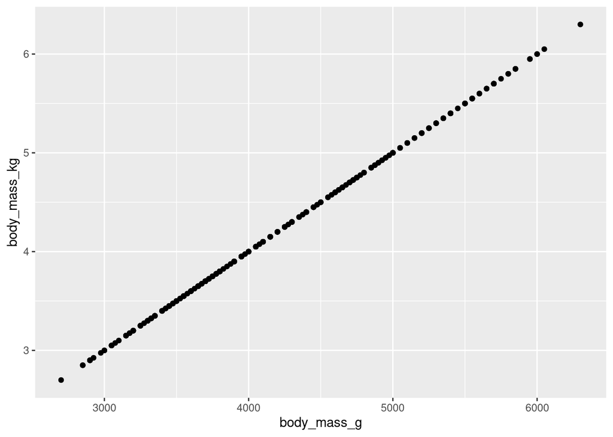

```r
pengu2 |>
  ggplot(aes(body_mass_g, body_mass_kg)) +
  geom_point()
```

### Exercise 9

How many male `Adelie` penguins have a body mass above 4 kg on each island? (Hint: Insert a code chunk and use `filter()`, and `count()` (or ``group_by()` and `summarise(n = n())`)).

```r
pengu |>
  filter(sex == "male", species == "Adelie", body_mass_g > 4000) |>
  count(island)
```

```
# A tibble: 3 × 2
  island        n
  <fct>     <int>
1 Biscoe       11
2 Dream        13
3 Torgersen    10
```